# STAT 571/701 Modern Data Mining, HW 2

# 4 Case 4: Simple Regression through simulations

## 4.1 Linear model through simulations

This exercise is designed to help you understand the linear model using simulations. In this exercise, we will generate $(x_i, y_i)$ pairs so that all linear model assumptions are met.

Presume that $\mathbf{x}$ and $\mathbf{y}$ are linearly related with a normal error $\boldsymbol{\varepsilon}$ , such that $\mathbf{y} = 1 + 1.2\mathbf{x} + \boldsymbol{\varepsilon}$. The standard deviation of the error $\varepsilon_i$ is $\sigma = 2$.

We can create a sample input vector ($n = 40$) for $\mathbf{x}$ with the following code:

```r
# Generates an input vector of size 40 with equally spaced values between 0 and 1, inclusive
set.seed(12)
x_1 <- seq(0, 1, length = 40)
```

### 4.1.1 Generate data

Create a corresponding output vector for $\mathbf{y}$ according to the equation given above. Use `set.seed(1)`. Then, create a scatterplot with $(x_i, y_i)$ pairs. Base R plotting is acceptable, but if you can, please attempt to use `ggplot2` to create the plot. Make sure to have clear labels and sensible titles on your plots.

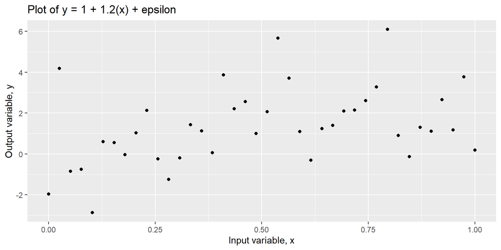

```r
#Creating error term and output vector y and saving that into a dataframe "case4_1":
set.seed(12)
epsilon <- rnorm(40, mean = 0, sd = 2)
case4_0 <- data.frame(x = x_1,
                    epsilon = epsilon)

case4_1 = case4_0 %>%
  mutate(y = 1 + 1.2*x + epsilon) %>%
  mutate(y_true = 1 +1.2*x)
#View(case4_1)

#Creating a scatterplot of the data:
case4_1 %>%
  ggplot(aes(x = x, y = y)) +
  geom_point() +
  labs(title ="Plot of y = 1 + 1.2(x) + epsilon",
       x = "Input variable, x",
       y = "Output variable, y")
```

### 4.1.2 Understand the model

1. Find the LS estimates of $\boldsymbol{\beta}_0$ and $\boldsymbol{\beta}_1$, using the `lm()` function. What are the true values of $\boldsymbol{\beta}_0$ and $\boldsymbol{\beta}_1$? Do the estimates look to be good?

```r
fit1 <- lm(y~x, case4_1)
summary(fit1)
```

```
##
## Call:
## lm(formula = y ~ x, data = case4_1)
##
## Residuals:
##    Min     1Q Median     3Q    Max
## -3.245 -1.081 -0.142  0.748  4.198
##
## Coefficients:
##             Estimate Std. Error t value Pr(>|t|)
## (Intercept)    0.116      0.547    0.21    0.833
## x              2.501      0.941    2.66    0.011 *
## ---
## Signif. codes:  0 '***' 0.001 '**' 0.01 '*' 0.05 '.' 0.1 ' ' 1
##
## Residual standard error: 1.76 on 38 degrees of freedom
## Multiple R-squared:  0.157,  Adjusted R-squared:  0.134
## F-statistic: 7.06 on 1 and 38 DF,  p-value: 0.0115
```

**Response:** The LS estimate of beta_0 is 0.116 and of beta_1 is 2.501. We would hope that the LS estimates of beta_0 and beta_1 would be close to 1 and 1.2, respectively. The estimates here are not perfect because of our error term with standard deviation of 2, which is relatively large compared to our x-values that range from 0 to 1.

2. What is your RSE for this linear model fit? Is it close to $\sigma = 2$?

```r
RSS <- sum((fit1$res)^2) #RSS, residual sum of squares #117.9
sqrt(RSS/fit1$df) #RSE, residual standard error #1.76
```

```
## [1] 1.76
```

```r
summary(fit1)$sigma #RSE, residual standard error #1.76
```

```
## [1] 1.76
```

**Response:** The RSE is 1.76, which is relatively close to 2.

2. What is the 95% confidence interval for $\boldsymbol{\beta}_1$? Does this confidence interval capture the true $\boldsymbol{\beta}_1$?

```r
#95% confidence interval is estimate +/- 2*SE(estimate)
2.501 - (2*0.941) #Lower limit = 0.619
```

```
## [1] 0.619
```

```r
2.501 + (2*0.941) #Upper limit = 4.38
```

```
## [1] 4.38
```

**Response:** The 95% confidence interval is [0.619, 4.38], and it captures the true beta_1 of 1.2.

3. Overlay the LS estimates and the true lines of the mean function onto a copy of the scatterplot you made above.

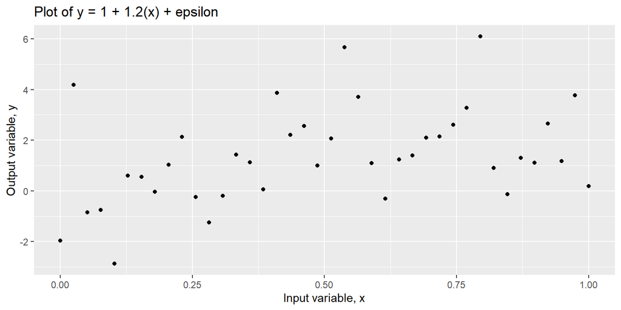

```r
#Scatterplot:
case4_1 %>%
  ggplot(aes(x = x, y = y)) +
  geom_point() +
  labs(title ="Plot of y = 1 + 1.2(x) + epsilon",
       x = "Input variable, x",
       y = "Output variable, y")
```

```r
#Model true line:
fit_true <- lm(y_true~x, case4_1)
summary(fit_true)
```

```
##
## Call:
## lm(formula = y_true ~ x, data = case4_1)
##
## Residuals:
##       Min        1Q    Median        3Q       Max
## -2.07e-16 -7.41e-17 -6.60e-18  3.80e-17  3.32e-16
##
## Coefficients:
##             Estimate Std. Error  t value Pr(>|t|)
## (Intercept) 1.00e+00   3.45e-17 2.90e+16   <2e-16 ***
## x           1.20e+00   5.94e-17 2.02e+16   <2e-16 ***
## ---
## Signif. codes:  0 '***' 0.001 '**' 0.01 '*' 0.05 '.' 0.1 ' ' 1
##
## Residual standard error: 1.11e-16 on 38 degrees of freedom
## Multiple R-squared:     1,   Adjusted R-squared:     1
## F-statistic: 4.08e+32 on 1 and 38 DF,  p-value: <2e-16
```

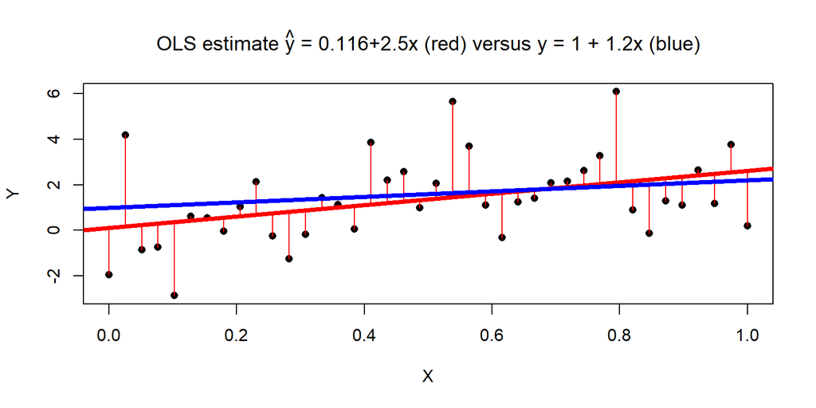

```r
#Scatterplot including both OLS and true lines:
plot(case4_1$x, case4_1$y,
     pch  = 16,
     xlab = "X",
     ylab = "Y",
     main = substitute(paste("OLS estimate ", hat(y), " = ", b0, "+", b1, "x", " (red) versus y = 1 + 1.2x (blue)"),
                       list(b0 = fit1$coefficients[1],
                            b1 = fit1$coefficients[2])))

abline(fit1, col="red", lwd=4)
segments(case4_1$x,
         case4_1$y,
         case4_1$x,
         fitted(fit1),
         col="red")

abline(fit_true, col="blue", lwd=4)
```

### 4.1.3 diagnoses

1. Provide residual plot where fitted $\mathbf{y}$-values are on the x-axis and residuals are on the y-axis.

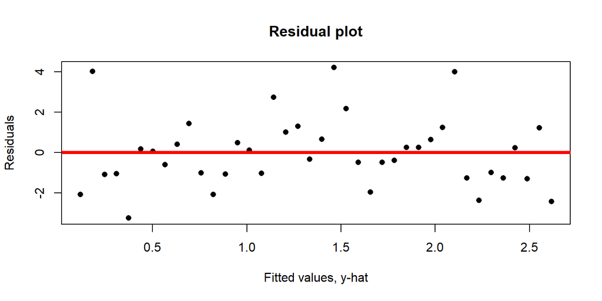

```r
#Resiudal plot
plot(fit1$fitted.values, fit1$residuals,
     pch = 16,
     main = "Residual plot",
     xlab = "Fitted values, y-hat",
     ylab = "Residuals")

abline(h=0, lwd=4, col="red")
```

2. Provide a normal QQ plot of the residuals.

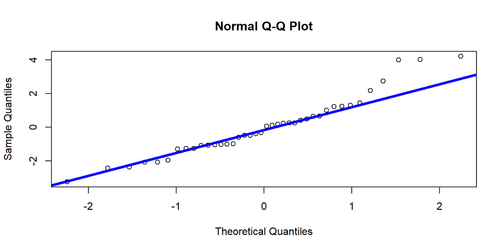

```r
#Normal Q-Q plot
  qqnorm(fit1$residuals)
  qqline(fit1$residuals, lwd=4, col="blue")
```

3. Comment on how well the model assumptions are met for the sample you used.

**Response:** To determine how reliable our linear model and the resulting estimates and confidence intervals are, we need to check the model assumptions in the following steps:

1. Check linearity first; if linearity is satisfied, then
2. Check homoscedasticity; if homoscedasticity is satisfied, then
3. Check normality.

We use the residual plot to check linearity and homoscedasticity. From our residual plot, we see that the residuals follow a relatively symmetric pattern with respect to the line residual = 0 in that we cannot discern any particular pattern of the residuals. Additionally, the residuals seem relatively evenly distributed within a band (satisfying homoscedasticity). However, we can see that the symmetry is not perfect.

We use the Normal Q-Q Plot to check normality. From our plot, we can see that the observations are relatively symmetric about the line (although some asymmentry is observed in the upper quantiles).

Thus, our linear model does not perfectly fit the data, but it does a relatively good job.

## 4.2 Understand sampling distribution and confidence intervals

This part aims to help you understand the notion of sampling statistics and confidence intervals. Let’s concentrate on estimating the slope only.

Generate 100 samples of size $n = 40$, and estimate the slope coefficient from each sample. We include some sample code below, which should guide you in setting up the simulation. Note: this code is easier to follow but suboptimal; see the appendix for a more optimal R-like way to run this simulation.

```r
# Inializing variables. Note b_1, upper_ci, lower_ci are vectors
set.seed(12)
x_2 <- seq(0, 1, length = 40)
n_sim <- 100              # number of simulations
b1 <- 0                   # n_sim many LS estimates of beta_1 (=1.2). Initialize to 0 for now
upper_ci <- 0             # upper bound for beta_1. Initialize to 0 for now.
lower_ci <- 0             # lower bound for beta_1. Initialize to 0 for now.
t_star <- qt(0.975, 38)

# Perform the simulation
for (i in 1:n_sim){
  y <- 1 + 1.2 * x_2 + rnorm(40, sd = 2)
  lse <- lm(y ~ x_2)
  lse_output <- summary(lse)$coefficients
  se <- lse_output[2, 2]
  b1[i] <- lse_output[2, 1]
  upper_ci[i] <- b1[i] + t_star * se
  lower_ci[i] <- b1[i] - t_star * se
}
results <- as.data.frame(cbind(se, b1, upper_ci, lower_ci))
```

1. Summarize the LS estimates of $\boldsymbol{\beta}_1$ (stored in `results$b1`). Does the sampling distribution agree with theory?

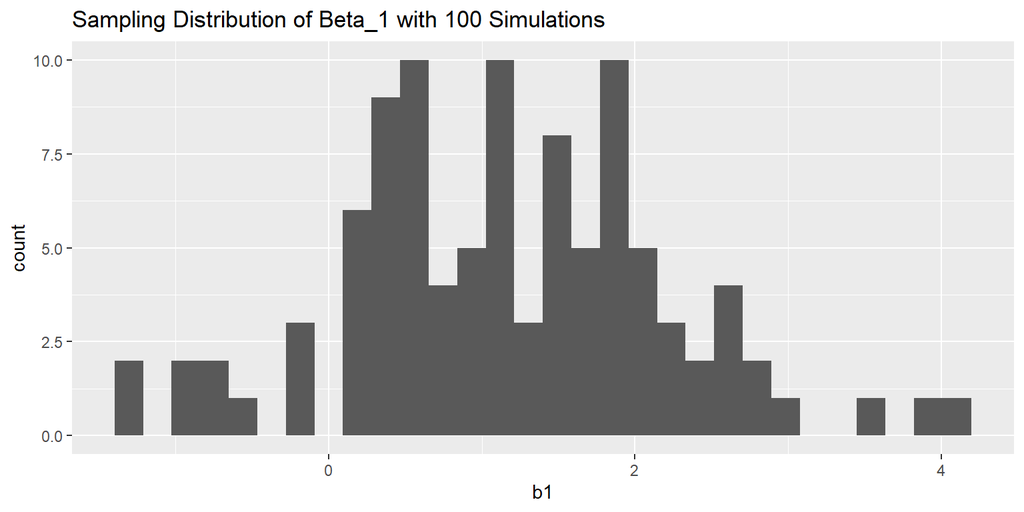

```r
#Histogram:
results %>%
  ggplot(aes(x = b1))+
  geom_histogram() +
  labs(title = "Sampling Distribution of Beta_1 with 100 Simulations")
```

**Response:** The sampling distribution approximates a Normal distribution about the true mean (beta_1 = 1.2) when the number of simulations tends toward infinity. From our histogram, we can see that the sampling distribution is roughly Normal (although not a perfect approximation). If we were to increase the number of simulations, we would see a better approximation of the Normal distribution. Refer to the histogram resulting from 10,000 simulations below:

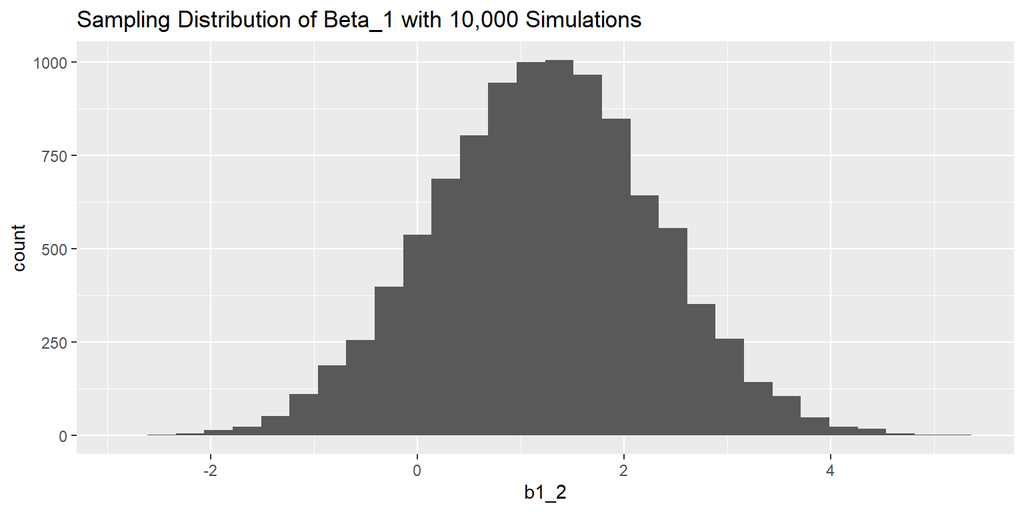

```r
# Inializing variables. Note b_1, upper_ci, lower_ci are vectors
set.seed(12)
x_3 <- seq(0, 1, length = 40)
n_sim_2 <- 10000              # number of simulations
b1_2 <- 0                   # n_sim many LS estimates of beta_1 (=1.2). Initialize to 0 for now
upper_ci_2 <- 0             # upper bound for beta_1. Initialize to 0 for now.
lower_ci_2 <- 0             # lower bound for beta_1. Initialize to 0 for now.
t_star_2 <- qt(0.975, 38)

# Perform the simulation
for (i in 1:n_sim_2){
  y_2 <- 1 + 1.2 * x_3 + rnorm(40, sd = 2)
  lse_2 <- lm(y_2 ~ x_3)
  lse_output_2 <- summary(lse_2)$coefficients
  se_2 <- lse_output_2[2, 2]
  b1_2[i] <- lse_output_2[2, 1]
  upper_ci_2[i] <- b1_2[i] + t_star_2 * se_2
  lower_ci_2[i] <- b1_2[i] - t_star_2 * se_2
}
results_2 <- as.data.frame(cbind(se_2, b1_2, upper_ci_2, lower_ci_2))

#Histogram:
results_2 %>%
  ggplot(aes(x = b1_2))+
  geom_histogram()+
  labs(title = "Sampling Distribution of Beta_1 with 10,000 Simulations")
```

2. How many of your 95% confidence intervals capture the true $\boldsymbol{\beta}_1$? Display your confidence intervals graphically.

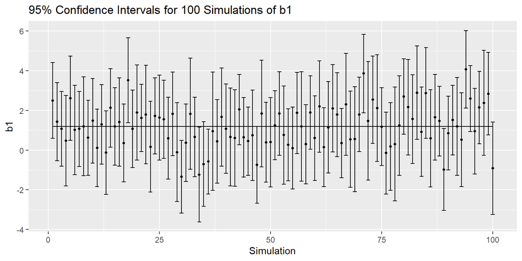

```
## FALSE  TRUE
##     8    92
```

```r
results1 = results %>%
  mutate(Simulation = 1:100) %>%
  mutate(contains_true = as.factor(ifelse(lower_ci <= 1.2 & upper_ci >= 1.2, "TRUE", "FALSE")))

summary(results1$contains_true) #92 confidence intervals capture the true beta_1

ggplot(results1, aes(x = Simulation, y = b1)) +
  geom_point(size = 1)+
  geom_errorbar(aes(ymax = upper_ci, ymin = lower_ci))+
  labs(title = "95% Confidence Intervals for 100 Simulations of b1")+
  geom_line(aes(y = 1.2))
```

**Response:** 92 of our confidence intervals capture the true beta_1. This is around what we would expect because we are using 95% confidence intervals.